# Об анализе зависимостей

Независимость случайных величин:
$$\displaystyle{{p_{\xi,\eta}(x, y_0)}\over{p_{\eta}(y_0)}} = p_\xi(x),$$
при таких $y_0$, что $p_{\eta}(y_0) ≠ 0$.

Для рассмотрения видов зависимости понадобится *функция условного математического ожидания*:
$$\phi(x) = \mathbf{E}\{\eta | \xi\},
\label{def1:ref}$$
где $\mathbf{E}\{\eta | \xi = x\} = \min_{\hat\eta \in \{\varphi(\xi)\}}\mathbf{E}(\eta - \hat\eta)^2$

В зависимости от вида функции условного математического ожидания (линейная, степенная и т.д.) и называется зависимость.

Линейная зависимость измеряется коэффициентом корреляции Пирсона:
$$\rho = \displaystyle{{cov(\xi,\eta)}\over{\sqrt{\mathbf{D}\xi}\sqrt{\mathbf{D}\eta}}},$$
где $cov(\xi,\eta) = \mathbf{E}\{(\xi - \mathbf{E}\xi)(\eta - \mathbf{E}\eta)\}$

Помимо коэффициента корреляции Пирсона, сущесвтует коэффициент корреляции Спирмена:
$$\rho_{S} = \rho(\mathrm{cdf}_{\xi}(\xi), \mathrm{cdf}_\eta(\eta)),$$

где $\mathrm{cdf}_{\xi}(\xi)$ — это функция распределения $\xi$ (сокращение от *cumulative distribution function*)

Разница между этими методами в том, что коэффициент Спирмена является мерой монотонной зависимости, в то время как коэффициент Пирсона — мера линейной зависимости. Если предположить, что зависимость монотонная и линейная, то коэффициент Спирмена более устойчив к выбросам, но менее точный, чем коэффициент Пирсона.

Приблизительное равенство $\rho$ и $\rho_{S}$ достигается в случае линейного условного математического ожидания, например, для нормально распределённых величин имеется следующая зависимость.
$$\rho = 2\sin(\frac{\pi}{6}\rho_{S})$$
Также отметим, что $\rho$ менее устойчив к аутлаерам, чем $\rho_{S}$.

```r
data <- read.csv("TeachingRatings.csv");
head(data)
```

|  | X | minority | age | gender | credits | beauty | eval | division | native | tenure | students | allstudents | prof |
| --- | --- | --- | --- | --- | --- | --- | --- | --- | --- | --- | --- | --- | --- |
| 1 | 1 | yes | 36 | female | more | 0.2899157 | 4.3 | upper | yes | yes | 24 | 43 | 1 |
| 2 | 2 | no | 59 | male | more | -0.7377322 | 4.5 | upper | yes | yes | 17 | 20 | 2 |
| 3 | 3 | no | 51 | male | more | -0.5719836 | 3.7 | upper | yes | yes | 55 | 55 | 3 |
| 4 | 4 | no | 40 | female | more | -0.6779634 | 4.3 | upper | yes | yes | 40 | 46 | 4 |
| 5 | 5 | no | 31 | female | more | 1.5097940 | 4.4 | upper | yes | yes | 42 | 48 | 5 |
| 6 | 6 | no | 62 | male | more | 0.5885687 | 4.2 | upper | yes | yes | 182 | 282 | 6 |

В этом наборе данных есть 13 переменных:

1. X — идентификатор курса;
2. minority — принадлежит ли преподаватель к меньшинству;
3. age — возраст преподавателя;
4. gender — пол преподавателя;
5. credits — является ли предмет факультативным;
6. beauty — оценка физического облика преподавателя группой из шести студентов, усредненная по шести участникам оценки, нормированная;
7. eval — оценка преподавания курса от 1 (очень плохо) до 5 (отлично);
8. division — является ли этот курс курсом высшего или низшего отделения (Курсы низшего отделения — это в основном большие курсы первокурсников и второкурсников);
9. native — является ли преподаватель носителем английского языка;
10. tenure — имеет ли преподаватель учёную степень;
11. students — количетсво студентов, участвовавших в оценке;
12. allstudents — общее количетсво студентов, обучавшихся на этом курсе;
13. prof — идентификатор преподавателя;

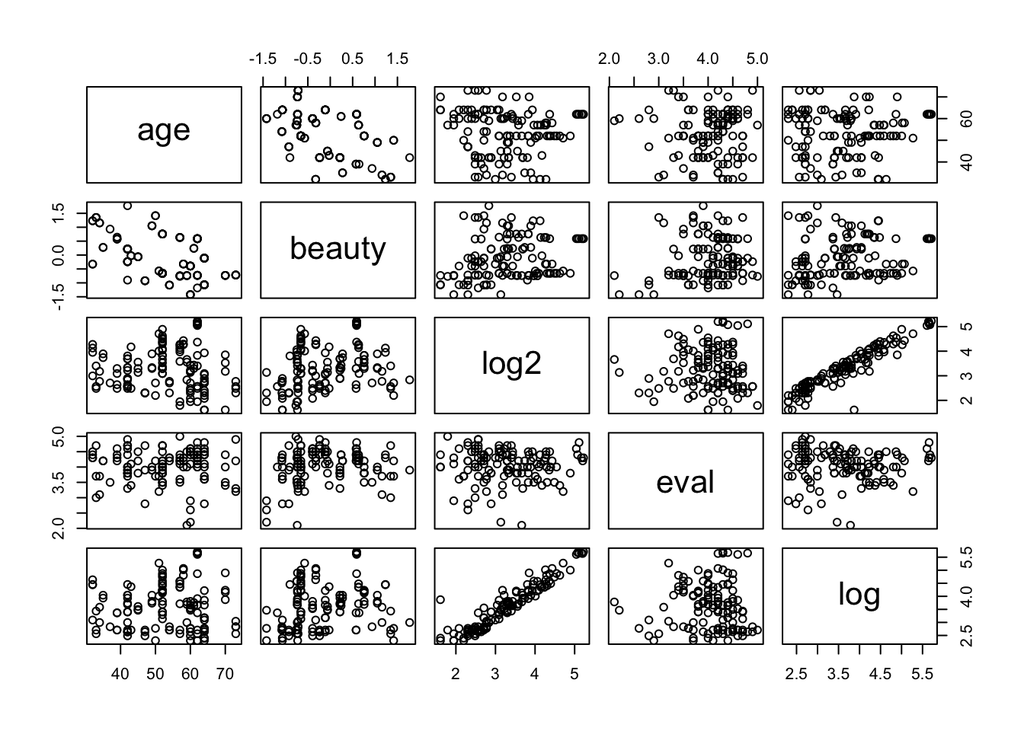

```r
filteredData_s = data[data$prof!=73, ]
filteredData_s['log'] = log(filteredData_s$allstudents)
filteredData_s['log2'] = log(filteredData_s$students)
subset_data = subset(filteredData_s, division=="upper" & minority=="no" & gender=="male" & credits=="more" & native=="yes" & tenure=="yes")
subset_data2 = subset(filteredData_s, division=="upper" & minority=="no" & gender=="female" & credits=="more" & native=="yes" & tenure=="yes")

pairs(~age+beauty+log2+eval+log,data=subset_data)
```

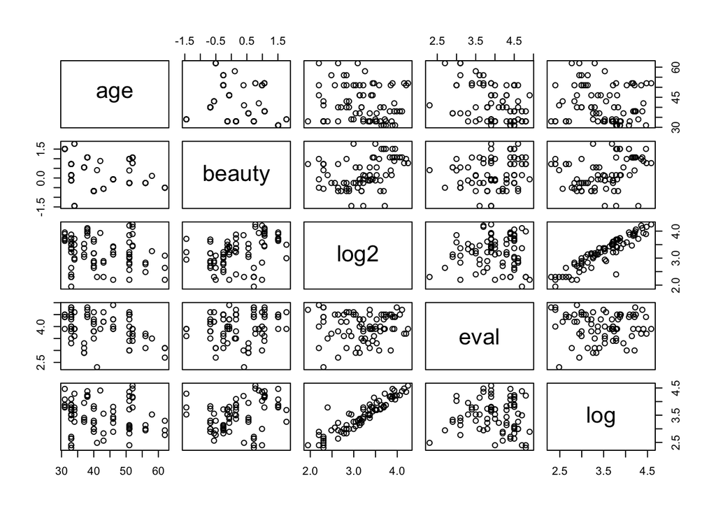

```r
pairs(~age+beauty+log2+eval+log,data=subset_data2)
```

## Подмножество male

Похоже, что *age* и *beauty* имеют линейную зависимость. Проверим. Посчитаем коэффициенты корреляции, а заодно и оценим статистическую значимость коэффициента корреляции Пирсона:

```r
cor.test(subset_data$age, subset_data$beauty)
```

```
##
##  Pearson's product-moment correlation
##
## data:  subset_data$age and subset_data$beauty
## t = -6.3661, df = 125, p-value = 3.355e-09
## alternative hypothesis: true correlation is not equal to 0
## 95 percent confidence interval:
##  -0.6159321 -0.3508424
## sample estimates:
##        cor
## -0.4948131
```

```r
cor.test(subset_data$age, subset_data$beauty, method="spearman")
```

```
##
##  Spearman's rank correlation rho
##
## data:  subset_data$age and subset_data$beauty
## S = 503099, p-value = 1.851e-08
## alternative hypothesis: true rho is not equal to 0
## sample estimates:
##        rho
## -0.4737376
```

Гипотиза о том, что коэффициент корреляции Пирсона равен нулю отвергается. Оценка коэффициента Пирсона равна **-0.4948131**, а Спирмена **-0.4737376**. Проверим, для сравнения, коэффициент корреляции между количеством студентов, проголосовавших в опросе и посетивших курс:

```r
cor.test(subset_data$log2, subset_data$log)
```

```
##
##  Pearson's product-moment correlation
##
## data:  subset_data$log2 and subset_data$log
## t = 32.482, df = 125, p-value < 2.2e-16
## alternative hypothesis: true correlation is not equal to 0
## 95 percent confidence interval:
##  0.9234612 0.9613986
## sample estimates:
##       cor
## 0.9455546
```

```r
cor.test(subset_data$log2, subset_data$log, method="spearman")
```

```
##
##  Spearman's rank correlation rho
##
## data:  subset_data$log2 and subset_data$log
## S = 19285, p-value < 2.2e-16
## alternative hypothesis: true rho is not equal to 0
## sample estimates:
##       rho
## 0.9435073
```

Гипотиза о том, что коэффициент корреляции Пирсона равен нулю отвергается. Оценка коэффициента Пирсона равна **0.9455546**, а Спирмена **0.9435073**. Это вполне согласуется с тем, что видно на графике. В нашем случае пропусков в данных нет, однако если бы они были, то нужно было бы применить одну из двух техник борьбы с ними:

- Удалить всю строку с пропуском (casewise) и анализировать индивидуумы с заполненными нужными полями
- Рассматривать заполненные поля при рассчёте корреляции (индивидуумы могут быть разными) В первом случае есть риск получить выборку слишком маленького размера, а во втором корреляция получается рассчитана на разных данных, возможно влияние какого-то третьего признака.

Из выше приведённых результатов видим, что заметной разницы между коэффициентамии корреляции Пирсона и Спирмена не выявлено.

```r
library(ppcor)
pcor(data.frame(age=subset_data$age, beauty=subset_data$beauty), method = "pearson")
```

```
## $estimate
##               age     beauty
## age     1.0000000 -0.4948131
## beauty -0.4948131  1.0000000
##
## $p.value
##                 age       beauty
## age    0.000000e+00 3.354513e-09
## beauty 3.354513e-09 0.000000e+00
##
## $statistic
##              age    beauty
## age     0.000000 -6.366148
## beauty -6.366148  0.000000
##
## $n
## [1] 127
##
## $gp
## [1] 0
##
## $method
## [1] "pearson"
```

```r
pcor(data.frame(log2=subset_data$age, log=subset_data$beauty), method = "spearman")
```

```
## $estimate
##            log2        log
## log2  1.0000000 -0.4737376
## log  -0.4737376  1.0000000
##
## $p.value
##             log2         log
## log2 0.00000e+00 1.85085e-08
## log  1.85085e-08 0.00000e+00
##
## $statistic
##           log2       log
## log2  0.000000 -6.014251
## log  -6.014251  0.000000
##
## $n
## [1] 127
##
## $gp
## [1] 0
##
## $method
## [1] "spearman"
```

## Подмножество female

Похоже, что *age* и *beauty* имеют линейную зависимость. Проверим. Посчитаем коэффициенты корреляции, а заодно и оценим статистическую значимость коэффициента корреляции Пирсона:

```r
cor.test(subset_data2$age, subset_data2$beauty)
```

```
##
##  Pearson's product-moment correlation
##
## data:  subset_data2$age and subset_data2$beauty
## t = -2.007, df = 78, p-value = 0.04822
## alternative hypothesis: true correlation is not equal to 0
## 95 percent confidence interval:
##  -0.420822613 -0.001973991
## sample estimates:
##        cor
## -0.2215948
```

```r
cor.test(subset_data2$age, subset_data2$beauty, method="spearman")
```

```
##
##  Spearman's rank correlation rho
##
## data:  subset_data2$age and subset_data2$beauty
## S = 110573, p-value = 0.007684
## alternative hypothesis: true rho is not equal to 0
## sample estimates:
##        rho
## -0.2959793
```

Гипотиза о том, что коэффициент корреляции Пирсона равен нулю отвергается. Оценка коэффициента Пирсона равна **-0.2215948**, а Спирмена **-0.2959793**. Проверим, для сравнения, коэффициент корреляции между количеством студентов, проголосовавших в опросе и посетивших курс:

```r
cor.test(subset_data2$log2, subset_data2$log)
```

```
##
##  Pearson's product-moment correlation
##
## data:  subset_data2$log2 and subset_data2$log
## t = 22.048, df = 78, p-value < 2.2e-16
## alternative hypothesis: true correlation is not equal to 0
## 95 percent confidence interval:
##  0.8901315 0.9535284
## sample estimates:
##       cor
## 0.9282953
```

```r
cor.test(subset_data2$log2, subset_data2$log, method="spearman")
```

```
##
##  Spearman's rank correlation rho
##
## data:  subset_data2$log2 and subset_data2$log
## S = 5520.9, p-value < 2.2e-16
## alternative hypothesis: true rho is not equal to 0
## sample estimates:
##       rho
## 0.9352916
```

Гипотиза о том, что коэффициент корреляции Пирсона равен нулю отвергается. Оценка коэффициента Пирсона равна **0.9282953**, а Спирмена **0.9352916**. Это вполне согласуется с тем, что видно на графике.

```r
pcor(data.frame(log2=subset_data2$log2, log=subset_data2$log), method = "pearson")
```

```
## $estimate
##           log2       log
## log2 1.0000000 0.9282953
## log  0.9282953 1.0000000
##
## $p.value
##              log2          log
## log2 0.000000e+00 2.979092e-35
## log  2.979092e-35 0.000000e+00
##
## $statistic
##          log2      log
## log2  0.00000 22.04818
## log  22.04818  0.00000
##
## $n
## [1] 80
##
## $gp
## [1] 0
##
## $method
## [1] "pearson"
```

```r
pcor(data.frame(log2=subset_data2$log2, log=subset_data2$log), method = "spearman")
```

```
## $estimate
##           log2       log
## log2 1.0000000 0.9352916
## log  0.9352916 1.0000000
##
## $p.value
##              log2          log
## log2 0.000000e+00 6.213714e-37
## log  6.213714e-37 0.000000e+00
##
## $statistic
##          log2      log
## log2  0.00000 23.34215
## log  23.34215  0.00000
##
## $n
## [1] 80
##
## $gp
## [1] 0
##
## $method
## [1] "spearman"
```

P-value для парных корреляций Пирсона и Спирмена также существенно меньше 0.05, что говорит об отсутсвии скрытого фактора зависимости